# Lab 2 - Team 3 - Research Proposal

Andrew Abrahamian, Victoria Hollingshead, Heesuk Jang, Hsi-sheng Wei

2022-07-19

## Research Proposal

1. Our team will be exploring the following research question: **Are wine ratings influenced by price, grape variety, region, year of vintage?**
- X will be price for a bottle of the wine (metric), grape type (categorical), region(category), and vintage (category).
  - X main concept - Price
  - X sub concepts - Grape variety, region, year of vintage
- Y will be wine rating in an ordinal scale, which is defined in the number of points Wine Enthusiast rated the wine on a scale of 80 -100 (Reviews for wines that score 1 - 79 are not available in the raw data set)
2. The data source will be from [Tidy Tuesday: Wine Enthusiast Reviews](https://github.com/rfordatascience/tidytuesday/tree/master/data/2019/2019-05-28).There are 129,971 rows and 13 columns. After removing reviews of identical wines and reviewers, the dataset is reduced to 108,290 rows. We are interested in filtering the dataset to the following sample frame, resulting in 26,244 observations.
- Reviews: The sampling frame is exclusively composed of anonymous reviewers. Because we have limited information on reviewer details, we assume all anonymous reviewers are unique, have equal access to all wines in our model, and are pulled from the same distribution.
  - Note on Reviews: Without any filtering, the dataset is overrepresented by 19 named reviewers. Reviews from 19 named reviewers make up over 80% of the overall dataset. We attribute this to the tendency for people who enjoy writing reviews to write more reviews. It is also possible that named reviewers are employed by Wine Enthusiasts, thus incentivizing their voluminous review count. In order to meet the IID requirements, we removed the reviews from these 19 named reviewers. We reason that removing this overrepresented group will allow us to minimize the bias in the sample distribution. Based on this, we assume all unknown reviewers have an equal opportunity to be selected.
- Universe
  - Countries: We will be restricting the sample frame to wines produced in the US. Assuming collinearity between country and region, this restriction allows us to use region as an X concept in our regression models.
  - Grape Varieties: We will be restricting our model to the top 3 grape varieties.
  - Region: We will be restricting our model to the top 3 regions in the US.
  - Vintage: We will include 5-6 vintage year categories.
3. The unit of observation is a unique product review per bottle of wine.

## Sush Feedback

1. the research question seems too broad. Can you recognize a primary predictor and build the study on top of it. You may eventually add other covariates to build a better model, but the study should revolve around the primary predictor of interest.
- Points ~ Price
- Options:
  - Points as a primary predictor. Requires Price to be treated as our Y variable
    - treat Price as our outcome

**Price (Y) ~ Points (X)** - grape variety could be more defensible (more valuable than country/region?) - vintage as a rule of thumb for predicting price ~ useful as a control variable

2. do you think it is a good idea to use an ordinal variable for the response. You could use the usual OLS regression, but your study would then have its limitations. Within this context, can you suggest a different response variable that is metric??
- Evaluate Price as our Y variable
3. consider having a prior hypothesis about the effect of X on Y?
- Write down our theory of the relationship
- Develop first hypothesis test
  - Null Hypothesis: No relationship between price (outcome) and points (predictor)
    - Assume the coefficient of points is equal to zero
  - Alt. Hypothesis: Assume that wine with higher rating will have a higher price controlling for vintage and grape varieties

Additional Covariates: * Vintage * Grape Variety * Region

Scope Decisions: * Global Model: country + vintage + grape variety <- eliminate due to issues w/ IID **Country-specific: region + vintage + grape variety**

[figure not shown]

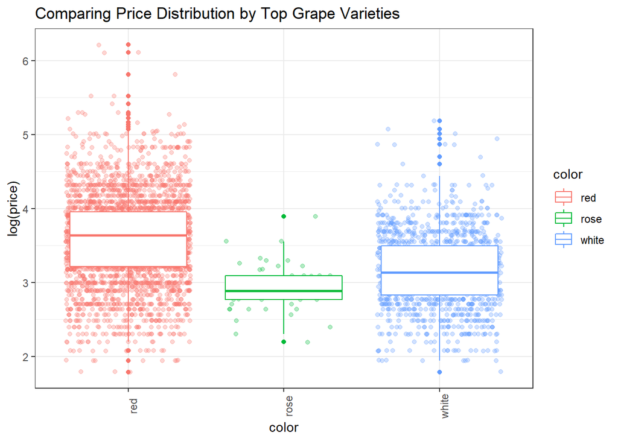

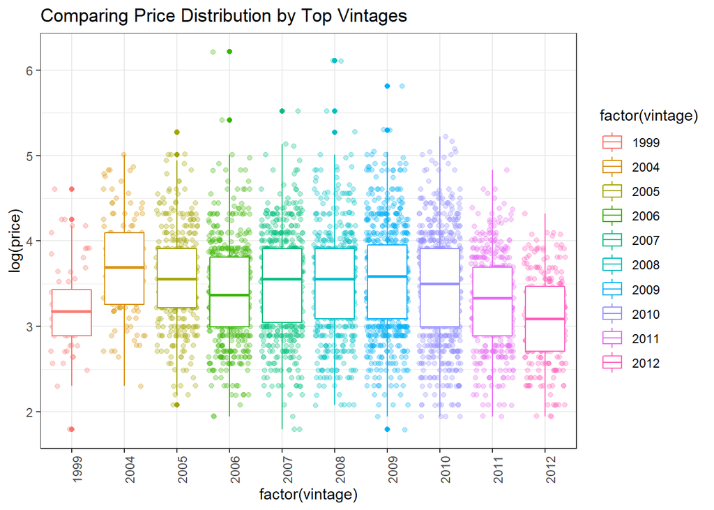

Our Theory: * type of grape likely covaries with region due to temperature and soil requirements * some variation could be explained by variety and by region * vintage may explain some variation, but it could be limited

## Main Variable Comparison

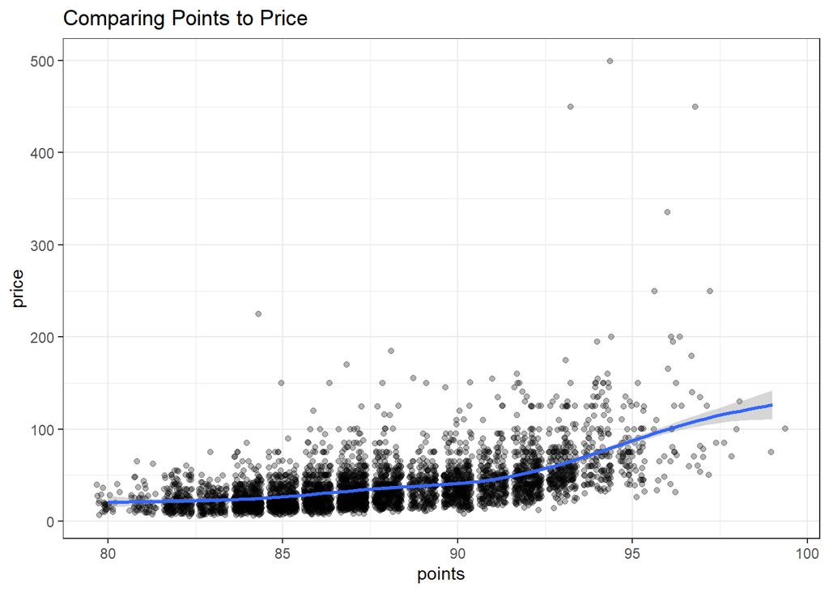

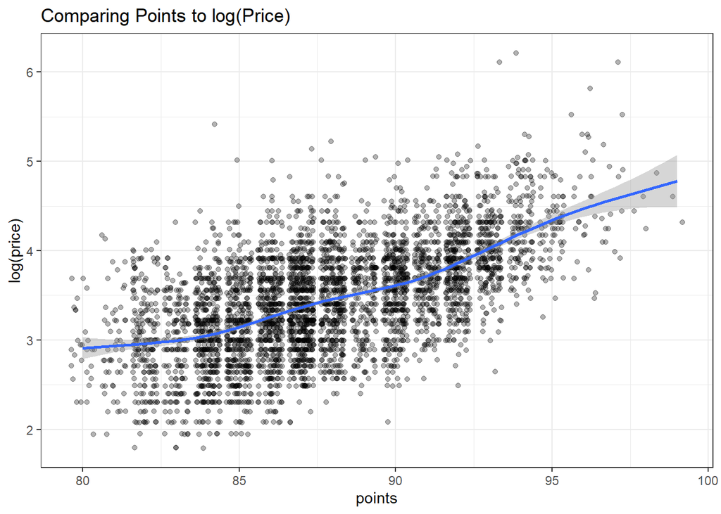

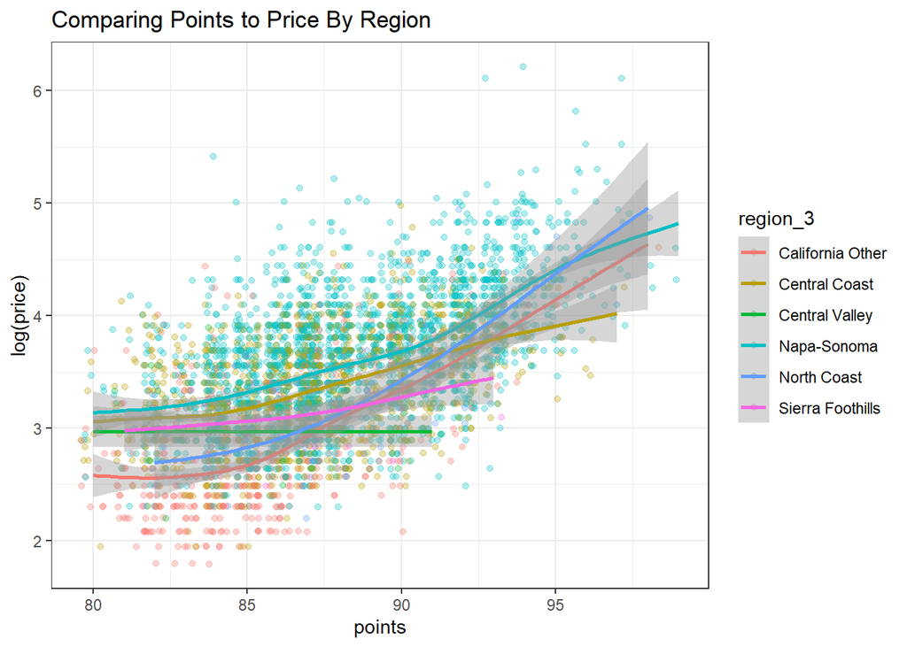

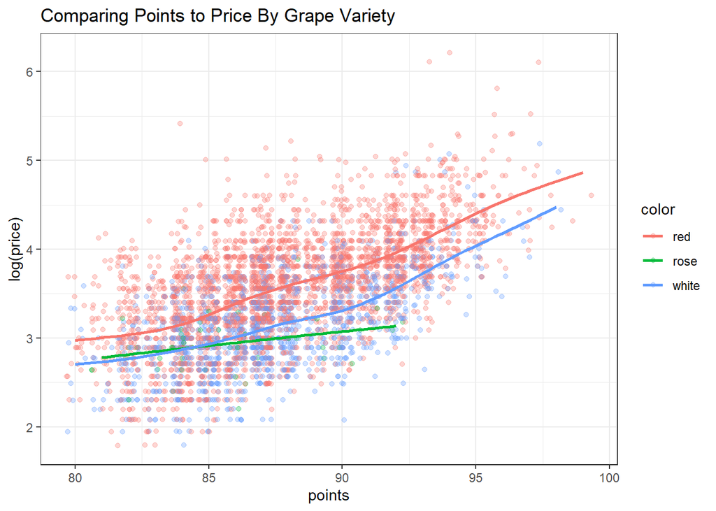

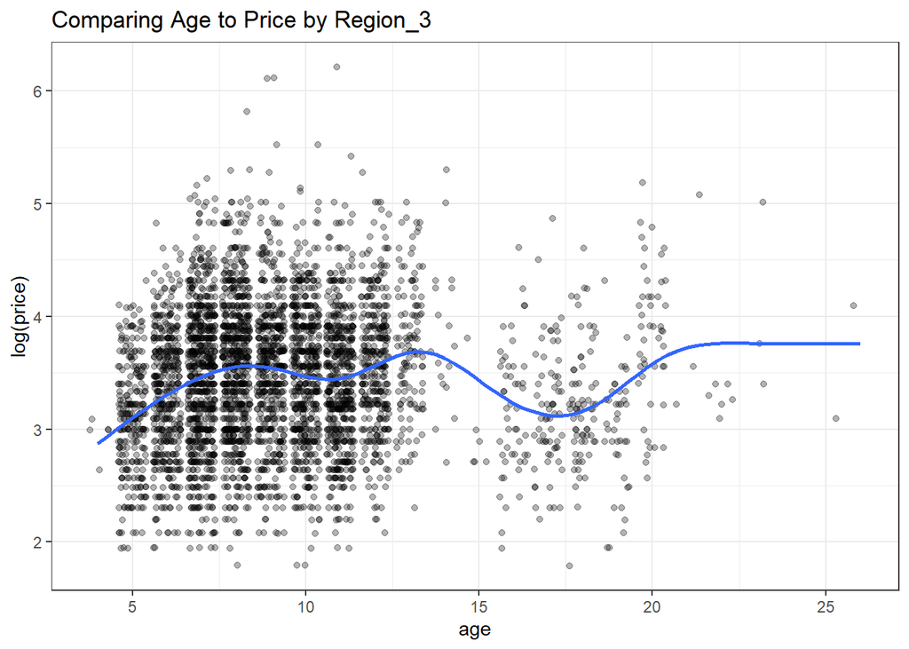

```
## [1] 0.5888724
```

## What Models Do We Want To Build

### Model #1: Our Primary Relationship

- log(Price) ~ Points
- Selecting the log-linear model to use points + other covariates to explain **changes in price** caused by a change in points (rating)

### Model #2:

- log(Price) ~ Points + variety

### Model #3:

- log(Price) ~ Points + variety + region_1

### Model #4:

- log(Price) ~ Points + variety + region_1 + vintage
  - Vintage as metric: we’re defining relationship between price x vintage
  - Vintage as ordinal: distinct intercepts between points x price relationship
    - ordinal can be subset of metric
  - Expect the relationship: older vintage (smaller #), higher the price

## What Is Needed Before Building Models

- Build hypothesis test + theory of relationship between points and log(price) ~ X and Y
- Identify specific layers of covariates to include in regression model

## Begin Model Building

#### Comparing Level-Level and Log-Level Model

```
##
## Call:
## lm(formula = price ~ points, data = train)
##
## Residuals:
##    Min     1Q Median     3Q    Max
## -45.66 -13.68  -4.06   8.30 436.22
##
## Coefficients:
##              Estimate Std. Error t value Pr(>|t|)
## (Intercept) -323.5353     9.0723  -35.66   <2e-16 ***
## points         4.1204     0.1033   39.91   <2e-16 ***
## ---
## Signif. codes:  0 '***' 0.001 '**' 0.01 '*' 0.05 '.' 0.1 ' ' 1
##
## Residual standard error: 24.09 on 4349 degrees of freedom
##   (3 observations deleted due to missingness)
## Multiple R-squared:  0.268,  Adjusted R-squared:  0.2679
## F-statistic:  1592 on 1 and 4349 DF,  p-value: < 2.2e-16
```

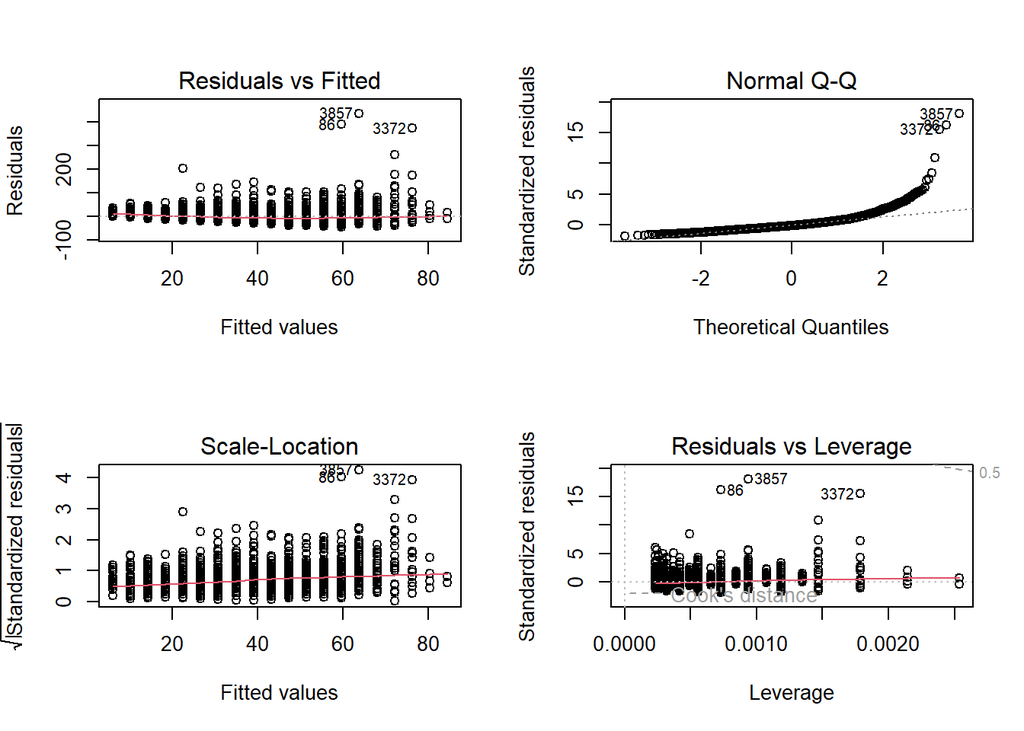

```
##
## Call:
## lm(formula = log(price) ~ points, data = train)
##
## Residuals:
##      Min       1Q   Median       3Q      Max
## -1.59562 -0.34285  0.00696  0.32167  2.34733
##
## Coefficients:
##              Estimate Std. Error t value Pr(>|t|)
## (Intercept) -5.419263   0.184777  -29.33   <2e-16 ***
## points       0.101048   0.002103   48.05   <2e-16 ***
## ---
## Signif. codes:  0 '***' 0.001 '**' 0.01 '*' 0.05 '.' 0.1 ' ' 1
##
## Residual standard error: 0.4907 on 4349 degrees of freedom
##   (3 observations deleted due to missingness)
## Multiple R-squared:  0.3468, Adjusted R-squared:  0.3466
## F-statistic:  2309 on 1 and 4349 DF,  p-value: < 2.2e-16
```

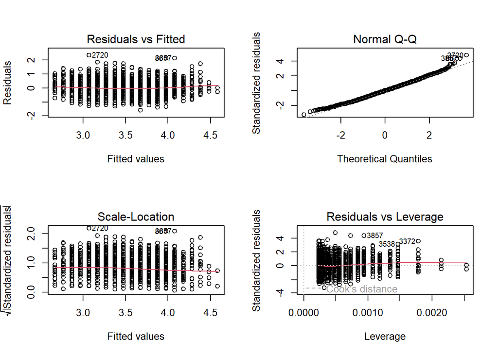

```
##
## t test of coefficients:
##
##               Estimate Std. Error t value  Pr(>|t|)
## (Intercept) -5.4192630  0.1859504 -29.144 < 2.2e-16 ***
## points       0.1010480  0.0021095  47.902 < 2.2e-16 ***
## ---
## Signif. codes:  0 '***' 0.001 '**' 0.01 '*' 0.05 '.' 0.1 ' ' 1
```

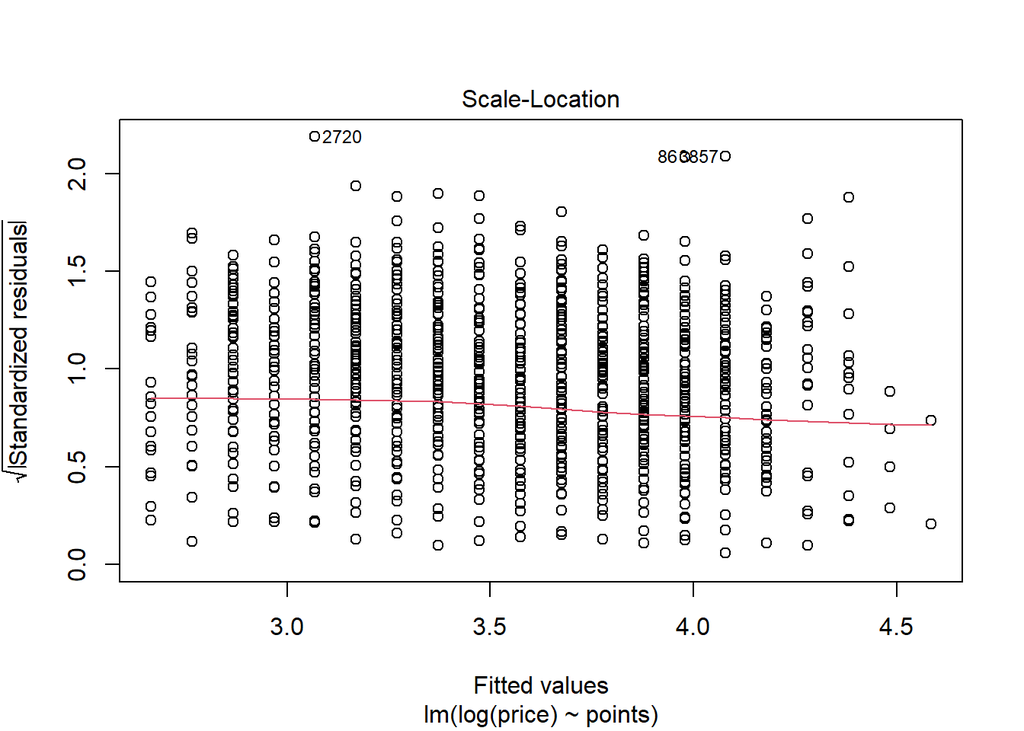

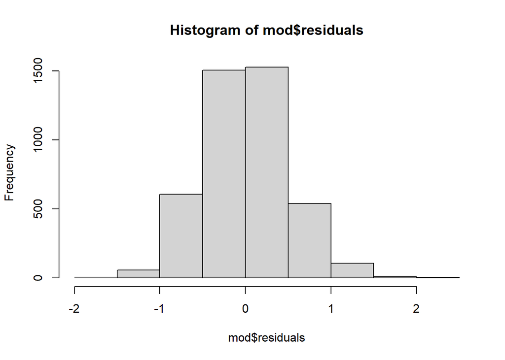

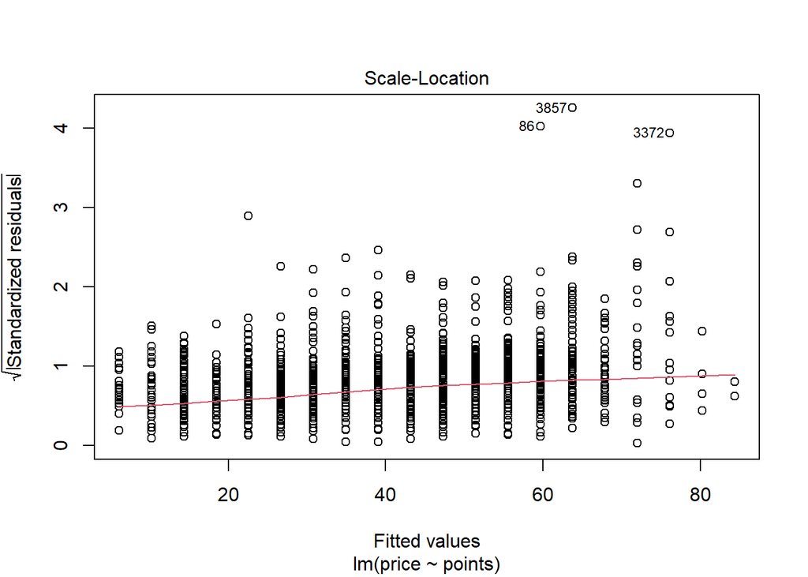

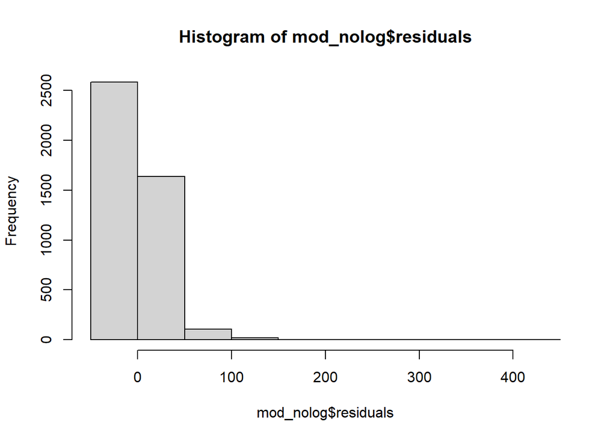

#### Does some regional detail add insight?

Yes, it explains +7% of variation in the model

```
##
## Call:
## lm(formula = log(price) ~ points + region_3, data = train)
##
## Residuals:
##      Min       1Q   Median       3Q      Max
## -1.45066 -0.32785 -0.01909  0.30370  2.17533
##
## Coefficients:
##                           Estimate Std. Error t value Pr(>|t|)
## (Intercept)              -4.596534   0.178086 -25.811  < 2e-16 ***
## points                    0.086849   0.002069  41.967  < 2e-16 ***
## region_3Central Coast     0.382666   0.024844  15.403  < 2e-16 ***
## region_3Central Valley    0.144859   0.089649   1.616 0.106201
## region_3Napa-Sonoma       0.542000   0.023583  22.983  < 2e-16 ***
## region_3North Coast       0.199413   0.069302   2.877 0.004028 **
## region_3Sierra Foothills  0.229197   0.059701   3.839 0.000125 ***
## ---
## Signif. codes:  0 '***' 0.001 '**' 0.01 '*' 0.05 '.' 0.1 ' ' 1
##
## Residual standard error: 0.4615 on 4344 degrees of freedom
##   (3 observations deleted due to missingness)
## Multiple R-squared:  0.4229, Adjusted R-squared:  0.4221
## F-statistic: 530.5 on 6 and 4344 DF,  p-value: < 2.2e-16
```

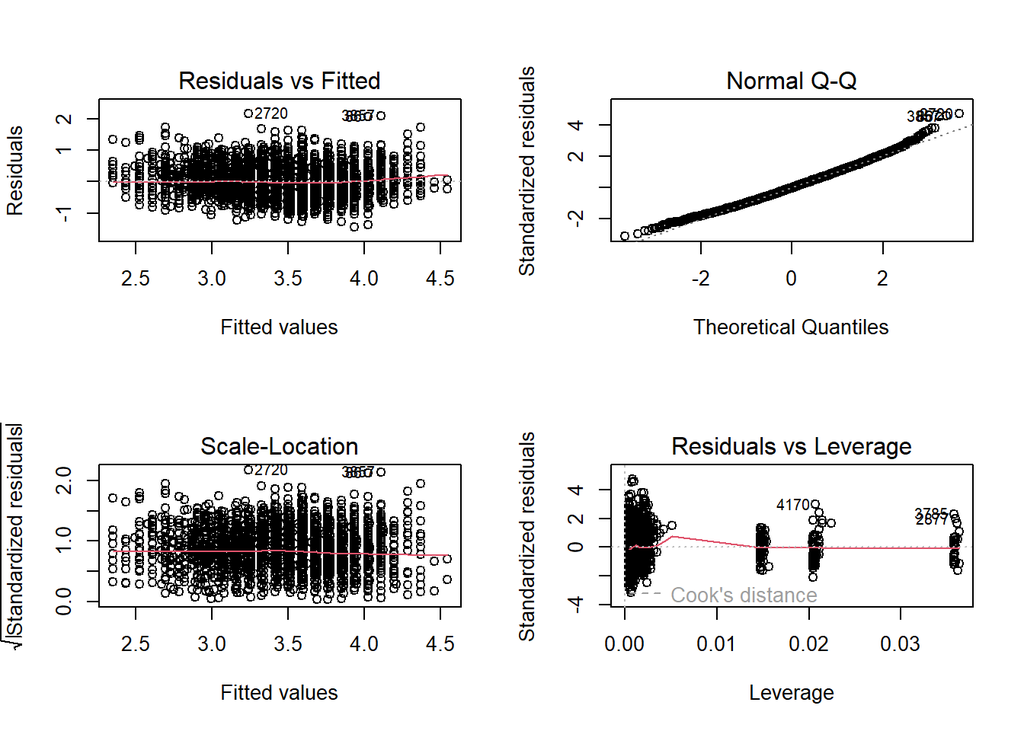

```
##              GVIF Df GVIF^(1/(2*Df))
## points   1.094792  1        1.046323
## region_3 1.094792  5        1.009098
```

```
##
## t test of coefficients:
##
##                           Estimate Std. Error  t value  Pr(>|t|)
## (Intercept)              -4.596534   0.178867 -25.6981 < 2.2e-16 ***
## points                    0.086849   0.002087  41.6143 < 2.2e-16 ***
## region_3Central Coast     0.382666   0.026140  14.6391 < 2.2e-16 ***
## region_3Central Valley    0.144859   0.088901   1.6294  0.103291
## region_3Napa-Sonoma       0.542000   0.025455  21.2926 < 2.2e-16 ***
## region_3North Coast       0.199413   0.075002   2.6587  0.007872 **
## region_3Sierra Foothills  0.229197   0.044782   5.1181  3.22e-07 ***
## ---
## Signif. codes:  0 '***' 0.001 '**' 0.01 '*' 0.05 '.' 0.1 ' ' 1
```

|  | Res.Df | Df | F | Pr(>F) |
| --- | --- | --- | --- | --- |
| 1 | 4349 | NA | NA | NA |
| 2 | 4344 | 5 | 103.7893 | 9.503938e-104 |

```
##
## Call:
## lm(formula = log(price) ~ points + region_3 + red, data = train)
##
## Residuals:
##      Min       1Q   Median       3Q      Max
## -1.34560 -0.29578 -0.01739  0.27734  2.06623
##
## Coefficients:
##                          Estimate Std. Error t value Pr(>|t|)
## (Intercept)              -4.57669    0.16669 -27.456  < 2e-16 ***
## points                    0.08420    0.00194  43.402  < 2e-16 ***
## region_3Central Coast     0.35543    0.02328  15.268  < 2e-16 ***
## region_3Central Valley    0.09729    0.08393   1.159  0.24646
## region_3Napa-Sonoma       0.49799    0.02215  22.488  < 2e-16 ***
## region_3North Coast       0.20923    0.06487   3.226  0.00127 **
## region_3Sierra Foothills  0.12899    0.05603   2.302  0.02137 *
## red                       0.35582    0.01434  24.806  < 2e-16 ***
## ---
## Signif. codes:  0 '***' 0.001 '**' 0.01 '*' 0.05 '.' 0.1 ' ' 1
##
## Residual standard error: 0.432 on 4343 degrees of freedom
##   (3 observations deleted due to missingness)
## Multiple R-squared:  0.4945, Adjusted R-squared:  0.4937
## F-statistic: 606.9 on 7 and 4343 DF,  p-value: < 2.2e-16
```

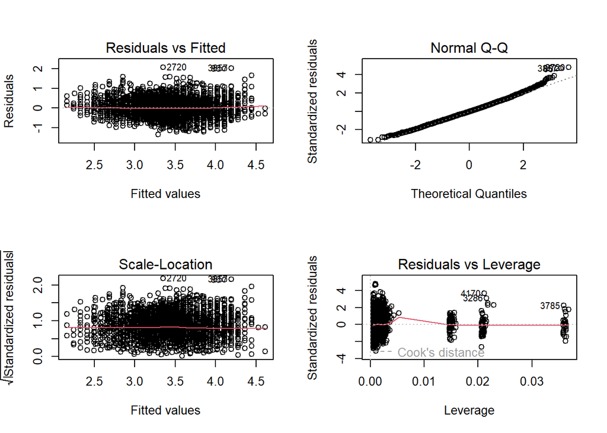

```
##              GVIF Df GVIF^(1/(2*Df))
## points   1.098121  1        1.047913
## region_3 1.106438  5        1.010166
## red      1.016899  1        1.008414
```

```
##
## t test of coefficients:
##
##                            Estimate Std. Error  t value  Pr(>|t|)
## (Intercept)              -4.5766895  0.1687189 -27.1261 < 2.2e-16 ***
## points                    0.0841994  0.0019702  42.7373 < 2.2e-16 ***
## region_3Central Coast     0.3554292  0.0249319  14.2560 < 2.2e-16 ***
## region_3Central Valley    0.0972920  0.0849832   1.1448  0.252339
## region_3Napa-Sonoma       0.4979879  0.0244435  20.3730 < 2.2e-16 ***
## region_3North Coast       0.2092338  0.0805271   2.5983  0.009400 **
## region_3Sierra Foothills  0.1289864  0.0446461   2.8891  0.003883 **
## red                       0.3558231  0.0135053  26.3469 < 2.2e-16 ***
## ---
## Signif. codes:  0 '***' 0.001 '**' 0.01 '*' 0.05 '.' 0.1 ' ' 1
```

[output not shown]

#### What about wine color?

```
##
## Call:
## lm(formula = log(price) ~ points + region_3 + color, data = train)
##
## Residuals:
##      Min       1Q   Median       3Q      Max
## -1.34600 -0.29514 -0.01661  0.27754  2.06541
##
## Coefficients:
##                           Estimate Std. Error t value Pr(>|t|)
## (Intercept)              -4.206922   0.167631 -25.096  < 2e-16 ***
## points                    0.084030   0.001943  43.242  < 2e-16 ***
## region_3Central Coast     0.356321   0.023285  15.303  < 2e-16 ***
## region_3Central Valley    0.096864   0.083924   1.154   0.2485
## region_3Napa-Sonoma       0.499134   0.022156  22.528  < 2e-16 ***
## region_3North Coast       0.208725   0.064861   3.218   0.0013 **
## region_3Sierra Foothills  0.133142   0.056092   2.374   0.0177 *
## colorrose                -0.441221   0.060609  -7.280 3.95e-13 ***
## colorwhite               -0.352315   0.014545 -24.222  < 2e-16 ***
## ---
## Signif. codes:  0 '***' 0.001 '**' 0.01 '*' 0.05 '.' 0.1 ' ' 1
##
## Residual standard error: 0.4319 on 4342 degrees of freedom
##   (3 observations deleted due to missingness)
## Multiple R-squared:  0.4948, Adjusted R-squared:  0.4938
## F-statistic: 531.5 on 8 and 4342 DF,  p-value: < 2.2e-16
```

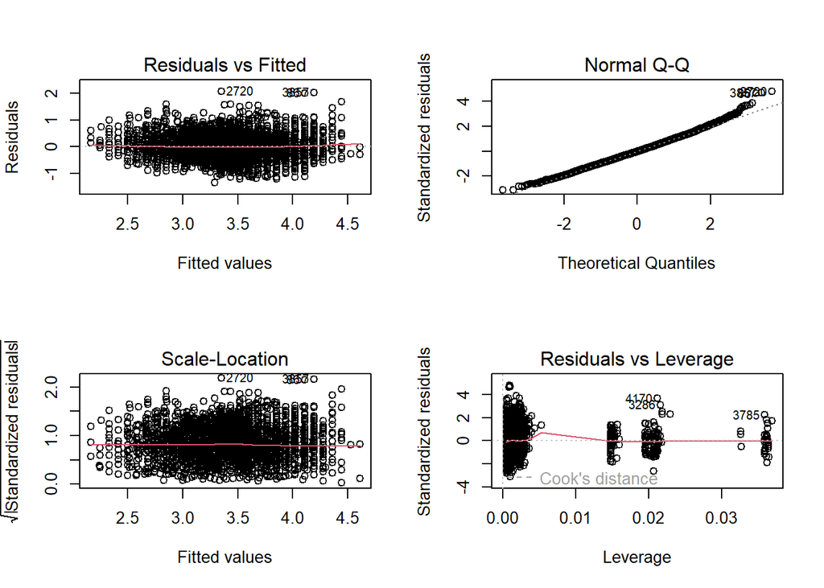

```
##
## t test of coefficients:
##
##                           Estimate Std. Error  t value  Pr(>|t|)
## (Intercept)              -4.206922   0.171074 -24.5912 < 2.2e-16 ***
## points                    0.084029   0.001976  42.5244 < 2.2e-16 ***
## region_3Central Coast     0.356321   0.024943  14.2853 < 2.2e-16 ***
## region_3Central Valley    0.096864   0.084906   1.1408  0.254003
## region_3Napa-Sonoma       0.499134   0.024451  20.4136 < 2.2e-16 ***
## region_3North Coast       0.208725   0.080484   2.5934  0.009536 **
## region_3Sierra Foothills  0.133142   0.044781   2.9732  0.002964 **
## colorrose                -0.441221   0.042883 -10.2891 < 2.2e-16 ***
## colorwhite               -0.352315   0.013718 -25.6835 < 2.2e-16 ***
## ---
## Signif. codes:  0 '***' 0.001 '**' 0.01 '*' 0.05 '.' 0.1 ' ' 1
```

|  | Res.Df | Df | F | Pr(>F) |
| --- | --- | --- | --- | --- |
| 1 | 4349 | NA | NA | NA |
| 2 | 4342 | 7 | 182.3666 | 1.589811e-237 |

```
##              GVIF Df GVIF^(1/(2*Df))
## points   1.102126  1        1.049822
## region_3 1.110284  5        1.010516
## color    1.023524  2        1.005830
```

#### What about vintage?

```
##
## Call:
## lm(formula = log(price) ~ points + region_3 + color + age, data = train)
##
## Residuals:
##      Min       1Q   Median       3Q      Max
## -1.34109 -0.29453 -0.01546  0.27667  2.06968
##
## Coefficients:
##                           Estimate Std. Error t value Pr(>|t|)
## (Intercept)              -4.191962   0.168050 -24.945  < 2e-16 ***
## points                    0.084154   0.001946  43.251  < 2e-16 ***
## region_3Central Coast     0.355000   0.023308  15.231  < 2e-16 ***
## region_3Central Valley    0.103770   0.084101   1.234  0.21732
## region_3Napa-Sonoma       0.498577   0.022159  22.500  < 2e-16 ***
## region_3North Coast       0.211874   0.064906   3.264  0.00111 **
## region_3Sierra Foothills  0.140109   0.056367   2.486  0.01297 *
## colorrose                -0.447024   0.060784  -7.354 2.28e-13 ***
## colorwhite               -0.354533   0.014653 -24.195  < 2e-16 ***
## age                      -0.002646   0.002124  -1.246  0.21289
## ---
## Signif. codes:  0 '***' 0.001 '**' 0.01 '*' 0.05 '.' 0.1 ' ' 1
##
## Residual standard error: 0.4319 on 4341 degrees of freedom
##   (3 observations deleted due to missingness)
## Multiple R-squared:  0.4949, Adjusted R-squared:  0.4939
## F-statistic: 472.7 on 9 and 4341 DF,  p-value: < 2.2e-16
```

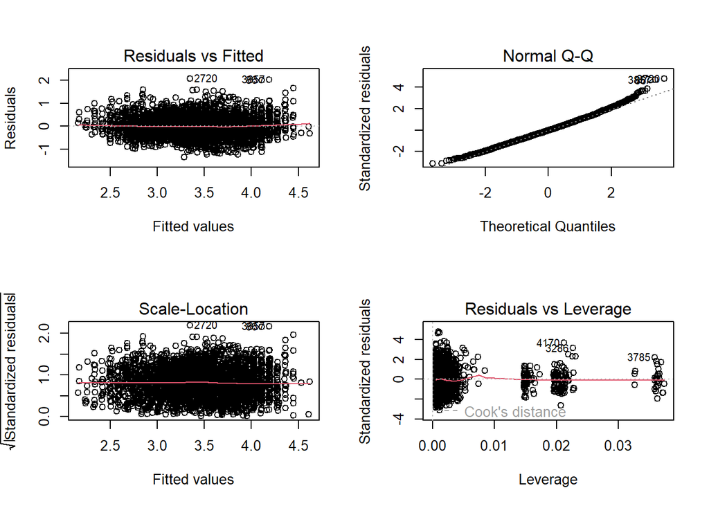

```
##
## t test of coefficients:
##
##                            Estimate Std. Error  t value  Pr(>|t|)
## (Intercept)              -4.1919617  0.1721607 -24.3491 < 2.2e-16 ***
## points                    0.0841537  0.0019754  42.5998 < 2.2e-16 ***
## region_3Central Coast     0.3550001  0.0249706  14.2167 < 2.2e-16 ***
## region_3Central Valley    0.1037699  0.0850409   1.2202  0.222442
## region_3Napa-Sonoma       0.4985769  0.0244911  20.3575 < 2.2e-16 ***
## region_3North Coast       0.2118736  0.0807259   2.6246  0.008705 **
## region_3Sierra Foothills  0.1401094  0.0452691   3.0950  0.001980 **
## colorrose                -0.4470236  0.0431728 -10.3543 < 2.2e-16 ***
## colorwhite               -0.3545326  0.0138818 -25.5394 < 2.2e-16 ***
## age                      -0.0026461  0.0022510  -1.1756  0.239839
## ---
## Signif. codes:  0 '***' 0.001 '**' 0.01 '*' 0.05 '.' 0.1 ' ' 1
```

|  | Res.Df | Df | F | Pr(>F) |
| --- | --- | --- | --- | --- |
| 1 | 4349 | NA | NA | NA |
| 2 | 4341 | 8 | 159.2658 | 5.082113e-236 |

```
##              GVIF Df GVIF^(1/(2*Df))
## points   1.105027  1        1.051203
## region_3 1.136712  5        1.012896
## color    1.043625  2        1.010732
## age      1.047616  1        1.023531
```

region_3Central Coast 0.383*** 0.356*** 0.355***  
(0.025) (0.023) (0.023)

region_3Central Valley 0.145 0.097 0.104  
(0.090) (0.084) (0.084)

region_3Napa-Sonoma 0.542*** 0.499*** 0.499***  
(0.024) (0.022) (0.022)

region_3North Coast 0.199*** 0.209*** 0.212***  
(0.069) (0.065) (0.065)

region_3Sierra Foothills 0.229*** 0.133** 0.140**  
(0.060) (0.056) (0.056)

colorrose -0.441*** -0.447***  
(0.061) (0.061)

colorwhite -0.352*** -0.355***  
(0.015) (0.015)

age -0.003  
(0.002)

Constant -5.419*** -4.597*** -4.207*** -4.192***  
(0.185) (0.178) (0.168) (0.168)

Observations 4,351 4,351 4,351 4,351  
R2 0.347 0.423 0.495 0.495  
Adjusted R2 0.347 0.422 0.494 0.494  
Residual Std. Error 0.491 (df = 4349) 0.462 (df = 4344) 0.432 (df = 4342) 0.432 (df = 4341)  
F Statistic 2,308.693*** (df = 1; 4349) 530.524*** (df = 6; 4344) 531.474*** (df = 8; 4342) 472.654*** (df = 9; 4341) ================================================================================================================================== Note: *p<0.1; **p<0.05;*** p<0.01

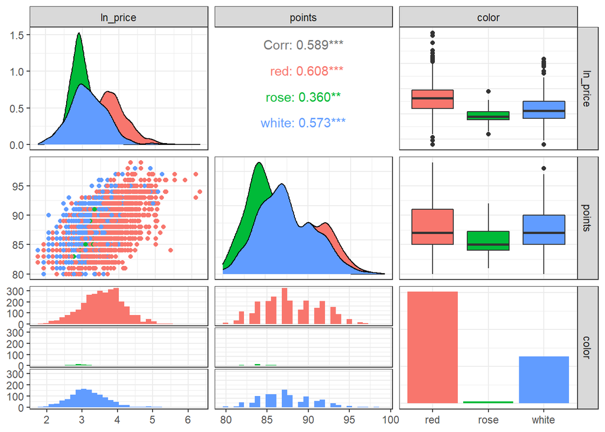

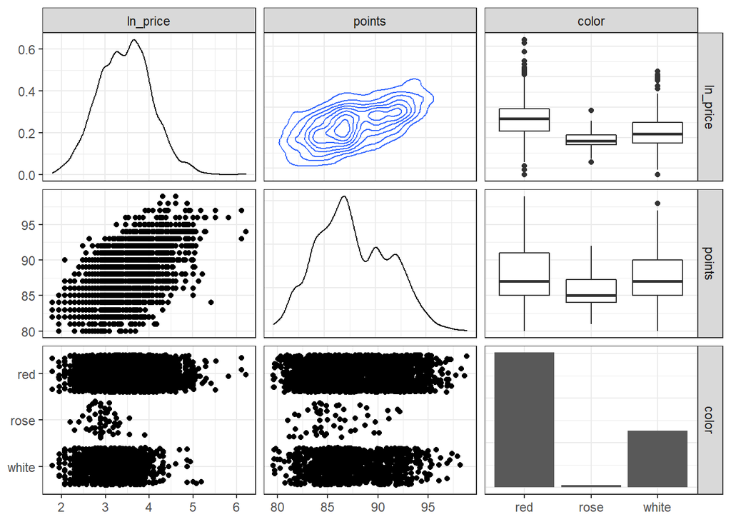

## Build Regression Models on Test Dataset